```python
import pandas as pd
import numpy as np
import matplotlib.pyplot as plt
import sklearn.metrics
import sklearn.feature_extraction.text
import sklearn.cluster
import matplotlib.cm as cm
from sklearn.datasets import make_blobs

#Ease of Life libraries used to simulate progression of slow algorithms
from ipywidgets import IntProgress
from IPython.display import display
import time
```

# Set-Up

Before any clustering algorithm is run, we need to set our data accordingly. We load all needed reviews and businesses from given and/or previous files, and begin to work with them:

1. We find all Restaurants with either "Burgers", "Italian" or "Japanese" tags to their categories.
2. We remove those that have more than 1 category from the above mentioned.
3. We mark all remaining restaurants with B, I and J for their true category.
4. We load the reviews and take those that belong to the restaurants we have gathered.
5. Finally, we mark each review with B,I,J accordingly.

```python
#Load Data
data = pd.read_csv("phily_businesses.csv", encoding="latin").dropna()
data.info()
```

```
<class 'pandas.core.frame.DataFrame'>
Int64Index: 10692 entries, 0 to 14568
Data columns (total 14 columns):
 #   Column        Non-Null Count  Dtype
---  ------        --------------  -----
 0   business_id   10692 non-null  object
 1   name          10692 non-null  object
 2   address       10692 non-null  object
 3   city          10692 non-null  object
 4   state         10692 non-null  object
 5   postal_code   10692 non-null  float64
 6   latitude      10692 non-null  float64
 7   longitude     10692 non-null  float64
 8   stars         10692 non-null  float64
 9   review_count  10692 non-null  int64
 10  is_open       10692 non-null  int64
 11  attributes    10692 non-null  object
 12  categories    10692 non-null  object
 13  hours         10692 non-null  object
dtypes: float64(4), int64(2), object(8)
memory usage: 1.2+ MB
```

```python
#Set Up and remove unwanted data
fixedData = data.copy()
#Set Categories as list for easier management
fixedData["categories"] = fixedData["categories"].apply(lambda x : [i.strip() for i in x.split(",")])
#Remove non-restaurants
fixedData = fixedData[fixedData.apply(lambda x : "Restaurants" in x.categories, axis=1)]

burgers = fixedData[fixedData.apply(lambda x : "Burgers" in x.categories, axis=1)]
italian = fixedData[fixedData.apply(lambda x : "Italian" in x.categories, axis=1)]
japanese = fixedData[fixedData.apply(lambda x : "Japanese" in x.categories, axis=1)]

onlyBurgers = burgers.loc[~burgers.index.isin(italian.index) & ~burgers.index.isin(japanese.index)]
onlyItalians = italian.loc[~italian.index.isin(burgers.index) & ~italian.index.isin(japanese.index)]
onlyJapanese = japanese.loc[~japanese.index.isin(italian.index) & ~japanese.index.isin(burgers.index)]
allData = onlyBurgers.append(onlyItalians.append(onlyJapanese))
allData["type"] = allData["categories"].apply(lambda x: "B" if "Burgers" in x else "J" if "Japanese" in x else "I")
allData.info()
```

```
<class 'pandas.core.frame.DataFrame'>
Int64Index: 951 entries, 18 to 14494
Data columns (total 15 columns):
 #   Column        Non-Null Count  Dtype
---  ------        --------------  -----
 0   business_id   951 non-null    object
 1   name          951 non-null    object
 2   address       951 non-null    object
 3   city          951 non-null    object
 4   state         951 non-null    object
 5   postal_code   951 non-null    float64
 6   latitude      951 non-null    float64
 7   longitude     951 non-null    float64
 8   stars         951 non-null    float64
 9   review_count  951 non-null    int64
 10  is_open       951 non-null    int64
 11  attributes    951 non-null    object
 12  categories    951 non-null    object
 13  hours         951 non-null    object
 14  type          951 non-null    object
dtypes: float64(4), int64(2), object(9)
memory usage: 118.9+ KB
```

```python
#Filtered Reviews is a file from Exercise 1 that contains the Philadelphian reviews with non-empty values.
reviews = pd.read_csv("filtered_reviews.csv", encoding="latin").dropna()
reviews.info()
```

```
<class 'pandas.core.frame.DataFrame'>
Int64Index: 893906 entries, 0 to 893905
Data columns (total 9 columns):
 #   Column       Non-Null Count   Dtype
---  ------       --------------   -----
 0   review_id    893906 non-null  object
 1   user_id      893906 non-null  object
 2   business_id  893906 non-null  object
 3   stars        893906 non-null  float64
 4   useful       893906 non-null  int64
 5   funny        893906 non-null  int64
 6   cool         893906 non-null  int64
 7   text         893906 non-null  object
 8   date         893906 non-null  object
dtypes: float64(1), int64(3), object(5)
memory usage: 68.2+ MB
```

# Vectorization

Using the Sklearn's TF-IDF Vectorizer, we can group each review by its business, and sum their text to a singular giant string for each business. Then, we pass it through the vectorizer, to get a vector for each business. This is passed to both Agglomerative Clustering and KMeans Clustering algorithms to produce the final results.

**Note:** The values used for the vectorizer as 3000 max features, min_df of 0 and max_df of 0.5. We decided on those values after our exploratory analysis that follows shortly after. **If the analysis' code is executed, the vectors will change in order to produce the needed results. This will be a problem for Part 2 if the code bellow is not re-run! Run the Vectorizer AGAIN before going to Step 2!**

```python
businessReviews = reviews.loc[reviews["business_id"].isin(allData["business_id"])]

vectorizer = sklearn.feature_extraction.text.TfidfVectorizer(max_features=3_000, stop_words="english",
                                                             min_df=0.0, max_df=0.5)

documents = businessReviews.groupby(["business_id"])["text"].sum().to_frame()
matrix = vectorizer.fit_transform(documents["text"]).toarray()
documents["vector"] = [matrix[i].tolist() for i in range(951)]
documents = documents.merge(right=allData[["business_id","type"]], left_on="business_id", right_on="business_id")
documents
```

|  | business_id | text | vector | type |
| --- | --- | --- | --- | --- |
| 0 | -AbzJTLQdbdQrhRzQLgsKA | Kingyo has summer appetizer specials for $3.00... | [0.0, 0.0, 0.0, 0.030736889028061373, 0.0, 0.0... | J |
| 1 | -HxLFWKVgXSU8JlR21PBkg | "Carluccio's: Way Delish" Ever find yourself ... | [0.0, 0.0, 0.0, 0.0, 0.0, 0.0, 0.0, 0.0, 0.0, ... | I |
| 2 | -LmhsdQproqCf5EQoD06rQ | Down in south Philly for a meeting at my daugh... | [0.0, 0.0, 0.0, 0.0, 0.0, 0.0, 0.0, 0.0, 0.0, ... | J |
| 3 | -MkngKKkTIVfnUbq2S1ucQ | Dee-frickin'-licious thick crust pizza!!! I or... | [0.0, 0.0, 0.0, 0.0, 0.0, 0.0, 0.0, 0.0, 0.0, ... | I |
| 4 | -PMXnNJ1D67NkAupRHNkpQ | I've always preferred domino's over pizza hut!... | [0.0, 0.039736145254252286, 0.0, 0.0, 0.0, 0.0... | I |
| ... | ... | ... | ... | ... |
| 946 | zUJMvjK6aBeQtVCowZ85-w | Excelent! Food is wondeful, hot, and fresh! Th... | [0.005148210873788151, 0.0, 0.0, 0.02192295948... | J |
| 947 | zeounyPVXFZEz1c9KtptLA | Pizza, wings, steaks are good.. chicken finger... | [0.0, 0.0, 0.0, 0.0, 0.0, 0.02758261847975047,... | I |
| 948 | zgX8sYCRGVJ9M5LETpJ60A | I popped in there one afternoon to pick up som... | [0.015592647397875465, 0.011095762520246587, 0... | B |
| 949 | zqisPpgCURrgLf4TVnI8RQ | This review is for poke bowl. Very fresh salad... | [0.0, 0.0, 0.0, 0.0, 0.0, 0.0, 0.0186473384996... | J |
| 950 | zzyx5x0Z7xXWWvWnZFuxlQ | Maybe the pizza is good here... but I can real... | [0.0, 0.0, 0.0, 0.0, 0.0, 0.0, 0.0, 0.0, 0.0, ... | I |

951 rows × 4 columns

```python
def measureAccuracy(print_results=True):
    types = ["B","I","J"]
    clusterCounts = []
    #First, count appearances of B, I and J in each cluster
    for cluster in range(3):
        clusterCount = [0,0,0]
        docs = documents.loc[documents["guesses"] == cluster]["type"]
        for t in docs:
            clusterCount[types.index(t)] += 1
        clusterCounts.append(clusterCount)

    #For each cluster, find their highest count of each category.
    #If a cluster has been nominated for a category, we ignore it in future iterations.
    finalCategories = []
    for category in range(len(types)):
        bestCluster = -1
        bestScore = -1
        for cluster in range(3):

            if cluster in finalCategories:
                continue

            _temp = clusterCounts[cluster][category]
            if _temp > bestScore:
                bestScore = _temp
                bestCluster = cluster
        finalCategories.append(bestCluster)

    results = documents.copy()
    results["guesses"] = results["guesses"].apply(lambda x : types[finalCategories[x]])

    guesses = len(results)
    correctGuesses = len(results[results.apply(lambda x : x.type == x.guesses, axis=1)])
    out = correctGuesses/guesses
    if print_results:
        print("Final score: ", out)
        print("Found ", correctGuesses, "/", guesses, " correct.")
    return out, results
```

```python
def generateConfusionMatrix(index=-1, name=""):
    cm = sklearn.metrics.confusion_matrix(results["type"],results["guesses"])

    if index != -1:
        ax = plt.subplot(220+index)
        plt.subplot(2,2,index)
        plt.title(name)
    else:
        ax = plt.subplot(111)
    ax.matshow(cm, cmap="hot")
    for i in range(len(cm)):
        for j in range(len(cm[0])):
            ax.text(x=j, y=i,s=cm[i, j], va='center', ha='center', size='xx-large', color="cyan")
```

# Step 1

## K-Means

First, K-Means. With the expected clusters of n=3, we get a score of around 67% accuracy.

```
Final score:  0.6750788643533123
Found  642 / 951  correct.
```

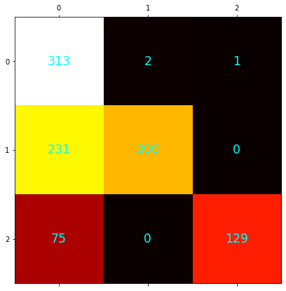

```python
#Part 1
plt.figure(figsize=(7,7))
kmeans = sklearn.cluster.KMeans(n_clusters=3)
documents["guesses"] = kmeans.fit_predict(documents["vector"].values.tolist())
acc, results = measureAccuracy()
generateConfusionMatrix()
```

```
Linkage:  ward
Final score:  0.6908517350157729
Found  657 / 951  correct.
----------------
Linkage:  complete
Final score:  0.555205047318612
Found  528 / 951  correct.
----------------
Linkage:  average
Final score:  0.334384858044164
Found  318 / 951  correct.
----------------
Linkage:  single
Final score:  0.3312302839116719
Found  315 / 951  correct.
----------------
```

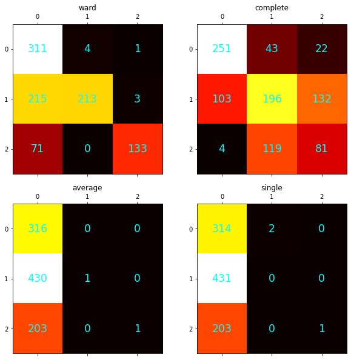

```python
C = 0
plt.figure(figsize=(10,10))
for link in ["ward", "complete", "average", "single"]:
    C += 1
    aggloCluster = sklearn.cluster.AgglomerativeClustering(n_clusters=3, linkage=link)
    documents["guesses"] = aggloCluster.fit_predict(documents["vector"].values.tolist())
    print("Linkage: ", link)
    acc, results = measureAccuracy()
    generateConfusionMatrix(index=C, name=link)
    print("----------------")
```

# Exploratory Analysis

The following 3 blocks of code were not directly part of this exercise, but were used to identify the ideal values of our vectorizer. **Ideally, those should not be executed when reviewing the data, as they have already provided any info we may require.**

By testing several values of Features and Min/Max DF, we can assume the ideal value to produce good results for both K-Means and Agglomerative.

- For Min and Max DF, both algorithms seem to agree that 0 and 0.5 accordingly are the values that prove more fruitful.
- As for Max Features, we sticked with the Agglomerative's decision. The reason being that KMeans provides similar results with 1000-3000 features, while Agglomerative has a terrible accuracy with 10 features.

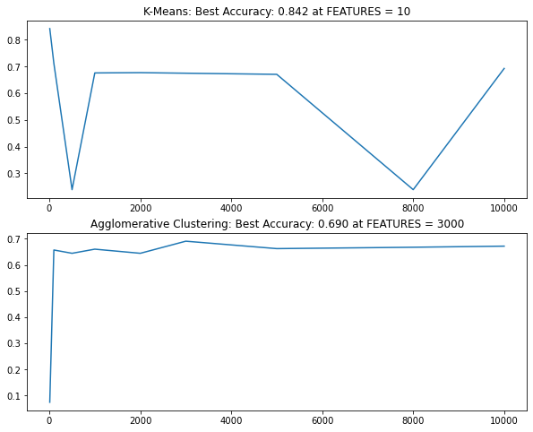

```python
#Exploration of data values - MAX FEATURES
#May take a minute. Note that running follow-up cells afterwards, will require to re-run the vectorizer above.
FEATURES = [10, 100, 500, 1000, 2000, 3000, 5000, 8000, 10_000]
kmeansResults = []
aggloResults = []

loadingBar = IntProgress(min=0, max=len(FEATURES)*3) # instantiate the bar
display(loadingBar)

for n_features in FEATURES:
    loadingBar.value += 1
    businessReviews = reviews.loc[reviews["business_id"].isin(allData["business_id"])]

    vectorizer = sklearn.feature_extraction.text.TfidfVectorizer(max_features=n_features, stop_words="english",
                                                                 min_df=0.0, max_df=0.5)
    loadingBar.value += 1
    documents = businessReviews.groupby(["business_id"])["text"].sum().to_frame()
    matrix = vectorizer.fit_transform(documents["text"]).toarray()
    documents["vector"] = [matrix[i].tolist() for i in range(951)]
    documents = documents.merge(right=allData[["business_id","type"]], left_on="business_id", right_on="business_id")

    kmeans = sklearn.cluster.KMeans(n_clusters=3)
    documents["guesses"] = kmeans.fit_predict(documents["vector"].values.tolist())
    acc, res = measureAccuracy(print_results=False)
    kmeansResults.append(acc)
    loadingBar.value += 1
    aggloCluster = sklearn.cluster.AgglomerativeClustering(n_clusters=3)
    documents["guesses"] = aggloCluster.fit_predict(documents["vector"].values.tolist())
    acc, res = measureAccuracy(print_results=False)
    aggloResults.append(acc)

plt.figure(figsize=(10,8))
bestResult = max(kmeansResults)
bestK = FEATURES[kmeansResults.index(bestResult)]
plt.subplot(211)
plt.plot(FEATURES, kmeansResults)
plt.title("K-Means: Best Accuracy: " + str(bestResult)[:5] + " at FEATURES = " + str(bestK))

bestResult = max(aggloResults)
bestK = FEATURES[aggloResults.index(bestResult)]
plt.subplot(212)
plt.plot(FEATURES, aggloResults)
plt.title("Agglomerative Clustering: Best Accuracy: " + str(bestResult)[:5] + " at FEATURES = " + str(bestK))
_null = plt.show()
```

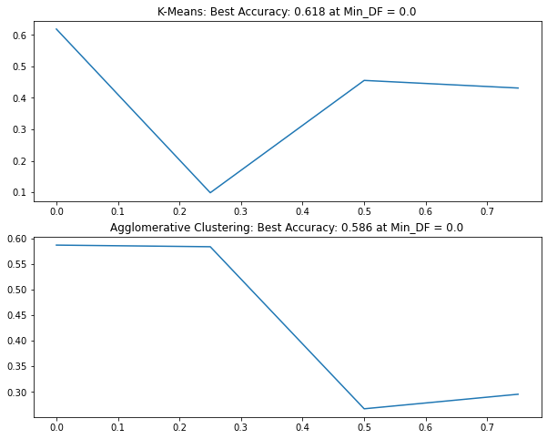

```python
#Exploration of data values - MIN_DF
#May take a minute. Note that running follow-up cells afterwards, will require to re-run the vectorizer above.
DF = [0.0, 0.25, 0.5, 0.75]
kmeansResults = []
aggloResults = []

loadingBar = IntProgress(min=0, max=len(DF)*3) # instantiate the bar
display(loadingBar)

for d in DF:
    loadingBar.value += 1
    businessReviews = reviews.loc[reviews["business_id"].isin(allData["business_id"])]

    vectorizer = sklearn.feature_extraction.text.TfidfVectorizer(max_features=1000, stop_words="english",
                                                                 min_df=d, max_df=1.0)
    loadingBar.value += 1
    documents = businessReviews.groupby(["business_id"])["text"].sum().to_frame()
    matrix = vectorizer.fit_transform(documents["text"]).toarray()
    documents["vector"] = [matrix[i].tolist() for i in range(951)]
    documents = documents.merge(right=allData[["business_id","type"]], left_on="business_id", right_on="business_id")

    kmeans = sklearn.cluster.KMeans(n_clusters=3)
    documents["guesses"] = kmeans.fit_predict(documents["vector"].values.tolist())
    acc, res = measureAccuracy(print_results=False)
    kmeansResults.append(acc)
    loadingBar.value += 1
    aggloCluster = sklearn.cluster.AgglomerativeClustering(n_clusters=3)
    documents["guesses"] = aggloCluster.fit_predict(documents["vector"].values.tolist())
    acc, res = measureAccuracy(print_results=False)
    aggloResults.append(acc)

plt.figure(figsize=(10,8))
bestResult = max(kmeansResults)
bestK = DF[kmeansResults.index(bestResult)]
plt.subplot(211)
plt.plot(DF, kmeansResults)
plt.title("K-Means: Best Accuracy: " + str(bestResult)[:5] + " at Min_DF = " + str(bestK))

bestResult = max(aggloResults)
bestK = DF[aggloResults.index(bestResult)]
plt.subplot(212)
plt.plot(DF, aggloResults)
plt.title("Agglomerative Clustering: Best Accuracy: " + str(bestResult)[:5] + " at Min_DF = " + str(bestK))
_null = plt.show()
```

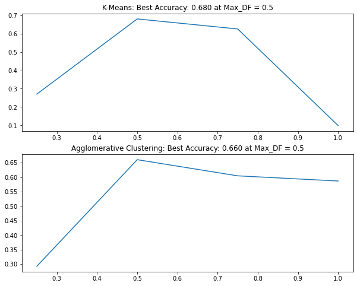

```python
#Exploration of data values - MAX_DF
#May take a minute. Note that running follow-up cells afterwards, will require to re-run the vectorizer above.
DF = [0.25, 0.5, 0.75, 1.0]
kmeansResults = []
aggloResults = []

loadingBar = IntProgress(min=0, max=len(DF)*3) # instantiate the bar
display(loadingBar)

for d in DF:
    loadingBar.value += 1
    businessReviews = reviews.loc[reviews["business_id"].isin(allData["business_id"])]

    vectorizer = sklearn.feature_extraction.text.TfidfVectorizer(max_features=1000, stop_words="english", min_df=0.0,
                                                                 max_df=d)
    loadingBar.value += 1
    documents = businessReviews.groupby(["business_id"])["text"].sum().to_frame()
    matrix = vectorizer.fit_transform(documents["text"]).toarray()
    documents["vector"] = [matrix[i].tolist() for i in range(951)]
    documents = documents.merge(right=allData[["business_id","type"]], left_on="business_id", right_on="business_id")

    kmeans = sklearn.cluster.KMeans(n_clusters=3)
    documents["guesses"] = kmeans.fit_predict(documents["vector"].values.tolist())
    acc, res = measureAccuracy(print_results=False)
    kmeansResults.append(acc)
    loadingBar.value += 1
    aggloCluster = sklearn.cluster.AgglomerativeClustering(n_clusters=3)
    documents["guesses"] = aggloCluster.fit_predict(documents["vector"].values.tolist())
    acc, res = measureAccuracy(print_results=False)
    aggloResults.append(acc)

plt.figure(figsize=(10,8))
bestResult = max(kmeansResults)
bestK = DF[kmeansResults.index(bestResult)]
plt.subplot(211)
plt.plot(DF, kmeansResults)
plt.title("K-Means: Best Accuracy: " + str(bestResult)[:5] + " at Max_DF = " + str(bestK))

bestResult = max(aggloResults)
bestK = DF[aggloResults.index(bestResult)]
plt.subplot(212)
plt.plot(DF, aggloResults)
plt.title("Agglomerative Clustering: Best Accuracy: " + str(bestResult)[:5] + " at Max_DF = " + str(bestK))
_null = plt.show()
```

# Step 2: K-Means Words

By using the vectorizer's vocabulary to fetch all the words on our list, and transforming the clustered datas' texts into a vector, we get the top TF-IDF scores for each word for each cluster. While the accuracy fails to impress, the words seem very well connected with their subject. Italian restaurants have words such as "Pasta", "Wine" and "italian", Japanese have "sushi" and fish related words, and finally Burgers have "burger", "cheesesteak" and "beer", all common items on such menus.

While impressive, a note to be made is that the Burger category is less specialized than the other two. The word "ramen" appears on the list, as well as several other words that don't neccecarly fit into the mix. The theory, as of now, is that the Burger cluster is not easily seperated into a whole single category by itself.

```python
#Part 2
kmeans = sklearn.cluster.KMeans(n_clusters=3)
documents["guesses"] = kmeans.fit_predict(documents["vector"].values.tolist())
inv_dic = {j:i for i,j in vectorizer.vocabulary_.items()}

for clusterType in ["J","B","I"]:
    clusterReviews = results.loc[results["guesses"] == clusterType]
    text = clusterReviews["text"].sum()

    vector = vectorizer.transform([text])
    bestScores = np.argsort(vector.toarray()[0])
    bestScores = np.flip(bestScores[-10:len(bestScores)])

    finalPrint = "For Cluster " + clusterType + " top words: "
    for i in bestScores:
        finalPrint += inv_dic[i] + ", "
    print(finalPrint[:-2])
```

```
For Cluster J top words: sushi, rolls, tuna, sashimi, salmon, rice, tempura, morimoto, omakase, japanese
For Cluster B top words: burger, ramen, cheesesteak, pat, burgers, beer, geno, wings, whiz, brunch
For Cluster I top words: pasta, italian, wine, gnocchi, dessert, reservation, meatballs, waiter, byob, veal
```

# Step 3: Metrics

```python
#Part 3
def getMetrics():
    print("=CLUSTER===PRECISION===RECALL==F1-SCORE==")
    for clusterType in ["J","B","I"]:
        clusterReviews = results.loc[results["guesses"] == clusterType]
        precision = sklearn.metrics.precision_score(clusterReviews["type"], clusterReviews["guesses"], average="macro", zero_division=0)
        recall = sklearn.metrics.recall_score(clusterReviews["type"], clusterReviews["guesses"], average="macro", zero_division=0)
        f1 = sklearn.metrics.f1_score(clusterReviews["type"], clusterReviews["guesses"], average="macro", zero_division=0)
        print("   ",clusterType, "      ", str(precision)[:5], "   ", str(recall)[:5], "   ", str(f1)[:5] , "  ")

    precision = sklearn.metrics.precision_score(results["type"], results["guesses"], average="macro", zero_division=0)
    recall = sklearn.metrics.recall_score(results["type"], results["guesses"], average="macro", zero_division=0)
    f1 = sklearn.metrics.f1_score(results["type"], results["guesses"], average="macro", zero_division=0)
    print("   ALL      ", str(precision)[:5], "   ", str(recall)[:5], "   ", str(f1)[:5])


kmeans = sklearn.cluster.KMeans(n_clusters=3)
documents["guesses"] = kmeans.fit_predict(documents["vector"].values.tolist())
acc, results = measureAccuracy(print_results=False)
print("==================KMEANS=================")
getMetrics()

aggloCluster = sklearn.cluster.AgglomerativeClustering(n_clusters=3)
documents["guesses"] = aggloCluster.fit_predict(documents["vector"].values.tolist())
acc, results = measureAccuracy(print_results=False)
print("==================AGGLOMERATIVE==========")
getMetrics()
```

```
==================KMEANS=================
=CLUSTER===PRECISION===RECALL==F1-SCORE==
    J        0.496     0.5     0.498
    B        0.168     0.333     0.224
    I        0.492     0.5     0.496
   ALL       0.828     0.698     0.693
==================AGGLOMERATIVE==========
=CLUSTER===PRECISION===RECALL==F1-SCORE==
    J        0.325     0.333     0.329
    B        0.165     0.333     0.221
    I        1.0     1.0     1.0
   ALL       0.824     0.687     0.677
```

```python
#Step 4
def measureGeneralAccuracy(print_results=True, n_clusters=3):
    types = ["B","I","J"]
    clusterCounts = []
    #First, count appearances of B, I and J in each cluster
    for cluster in range(n_clusters):
        clusterCount = [0,0,0]
        docs = documents.loc[documents["guesses"] == cluster]["type"]
        for t in docs:
            clusterCount[types.index(t)] += 1
        clusterCounts.append(clusterCount)

    finalCategories = []
    for cluster in range(n_clusters):
        finalCategories.append(np.argmax(clusterCounts[cluster]))

    results = documents.copy()
    results["guesses"] = results["guesses"].apply(lambda x : types[finalCategories[x]])

    guesses = len(results)
    correctGuesses = len(results[results.apply(lambda x : x.type == x.guesses, axis=1)])
    out = correctGuesses/guesses
    if print_results:
        print("Final score: ", out)
        print("Found ", correctGuesses, "/", guesses, " correct.")

    return out, results
```

# Step 4: Cluster Analysis

As mentioned above, the idea that the Burgers category (or even another category) can be split into more for better results is not strange. To test that, we will explore for a different amount of clusters, how good our clustering becomes.

## SSE Diagram

Using K-Means' Inertia value, we can calculate the overall distance of each point from its cluster. By testing clusters K from 2 to 10, we form a graph showing the density of each cluster. As expected, the higher tha amount of clusters, the lower the total SSE score becomes.

However, the slope appears to be steadily declining. This does not show the Elbow/Knee Effect, proving to be non-ideal to judge the amount of Clusters we need. If we are to take something from this, is that the higher the amount of clusters, the better; therefore the clusters should be around 5 to 10.

## Silhouette Coefficient

This time, we measure the connectivity of each point to its cluster, as well as the difference from other clusters. We want points close to their center, and as far away as possible from other. As expected, the value increases the more clusters we add, but this time we see a sudden spike around 8 clusters.

## Conclusion

With the SSE showing no ideal results, we turn to SC to give us the results we want, while keeping in mind that the higher the number of clusters, the less SSE we have. SC spikes at 8 clusters, as well as 10, giving us the two best canditates.

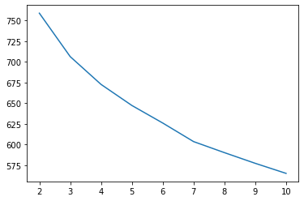

```python
SSE = []
MAX_K = 10
loadingBar = IntProgress(min=0, max=MAX_K-1) # instantiate the bar
display(loadingBar)

for k in range(2,MAX_K+1):
    kmeans = sklearn.cluster.KMeans(n_clusters=k)
    kmeans.fit(documents["vector"].values.tolist())
    SSE.append(kmeans.inertia_)
    loadingBar.value += 1

plt.plot(range(2,MAX_K+1), SSE)
```

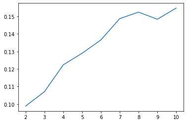

```python
COEFF = []
MAX_K = 10
loadingBar = IntProgress(min=0, max=MAX_K-1) # instantiate the bar
display(loadingBar)

for k in range(2,MAX_K+1):
    kmeans = sklearn.cluster.KMeans(n_clusters=k)
    documents["guesses"] = kmeans.fit_predict(documents["vector"].values.tolist())
    score = sklearn.metrics.silhouette_score(documents["vector"].values.tolist(), documents["guesses"].values.tolist())
    COEFF.append(score)
    loadingBar.value += 1

plt.plot(range(2,MAX_K+1), COEFF)
```

# Silhouette Analysis

With the ideal amount of clusters being 8 and 10, we decide to explore our data with more precision. By using the following code, we can plot each Silhouette Plot for each clusters' size.

Each cluster is represented by its own unique color, while each point is represented by a horizontal line, colored according to its cluster. The length of the line represents to total Silhouette Coefficient score.

Overall, we want 3 things:

- Each cluster to have somewhat equal amount of data
- Most, if not all, points of a cluster to surpass the mean SC score (red dotted line)
- We want the least amount of negative SC scores overall.

Code Source: https://scikit-learn.org/stable/auto_examples/cluster/plot_kmeans_silhouette_analysis.html

```
For n_clusters = 2 The average silhouette_score is : 0.09883082001485248
For n_clusters = 3 The average silhouette_score is : 0.10705411289367715
For n_clusters = 4 The average silhouette_score is : 0.12238565372355384
For n_clusters = 5 The average silhouette_score is : 0.13152576897345952
For n_clusters = 6 The average silhouette_score is : 0.1394012294151088
For n_clusters = 7 The average silhouette_score is : 0.14870077160784187
For n_clusters = 8 The average silhouette_score is : 0.15553402800220545
For n_clusters = 9 The average silhouette_score is : 0.15249760744088825
For n_clusters = 10 The average silhouette_score is : 0.15731557089597714
```

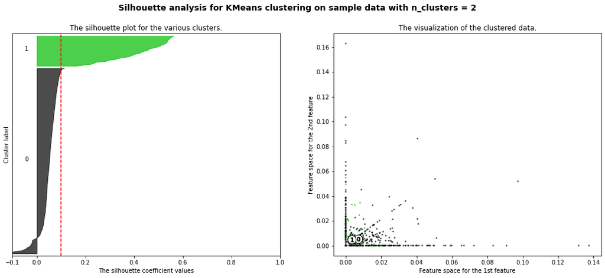

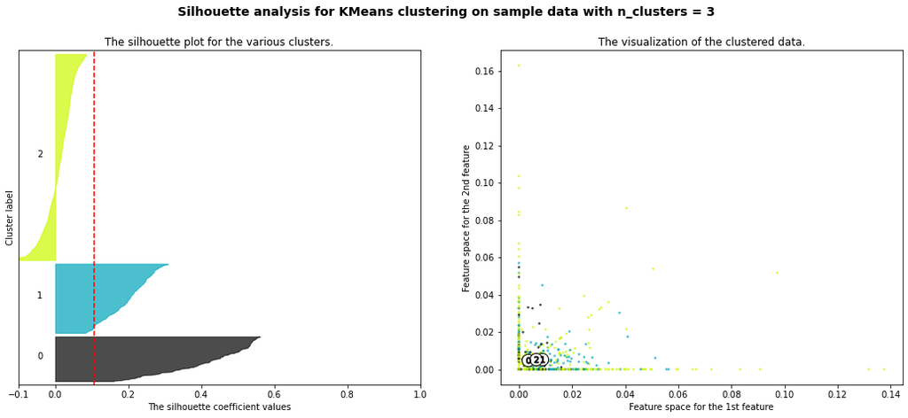

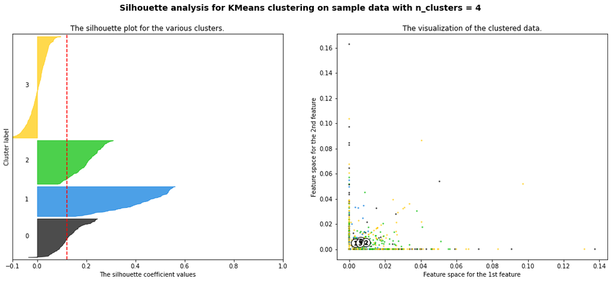

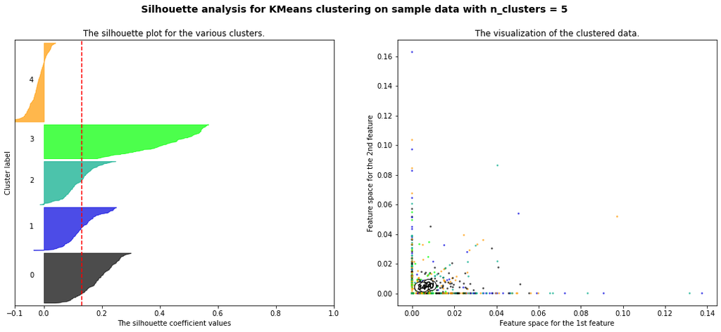

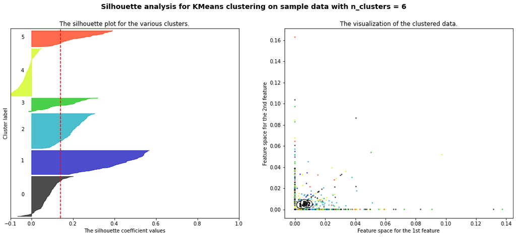

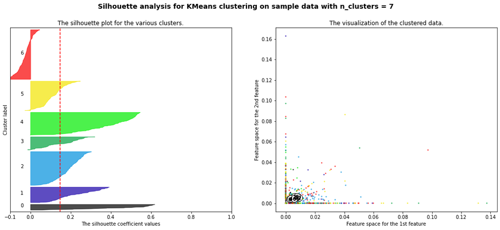

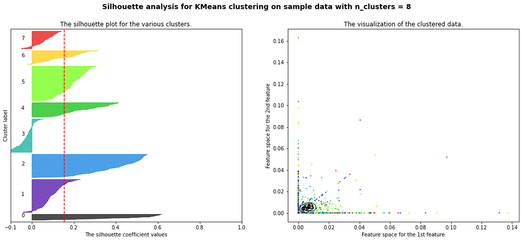

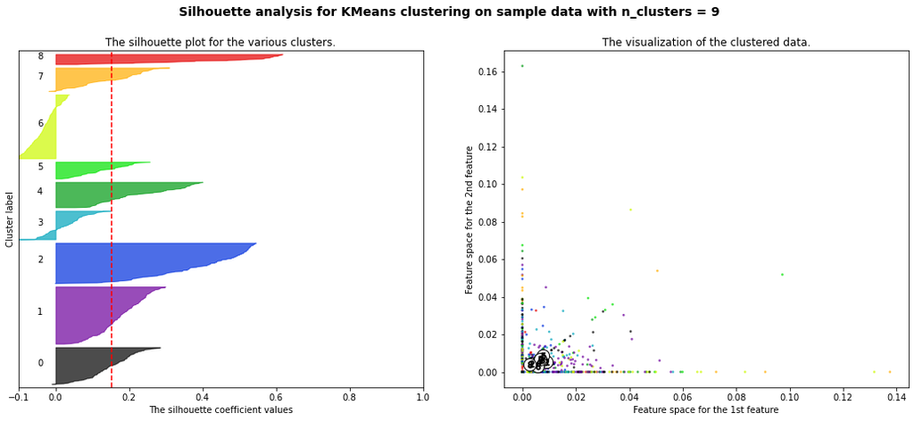

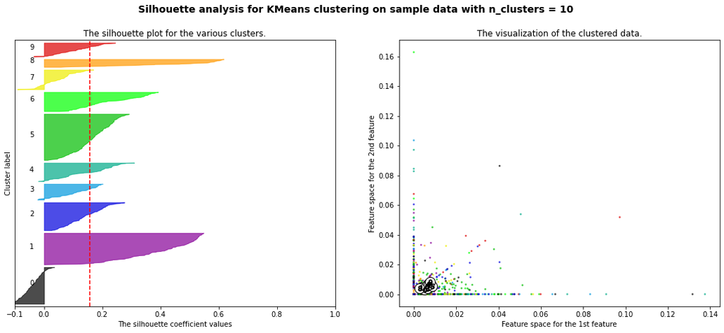

```python
X=np.array(documents["vector"].values.tolist())

for n_clusters in range(2,11):
    # Create a subplot with 1 row and 2 columns
    fig, (ax1, ax2) = plt.subplots(1, 2)
    fig.set_size_inches(18, 7)

    # The 1st subplot is the silhouette plot
    # The silhouette coefficient can range from -1, 1 but in this example all
    # lie within [-0.1, 1]
    ax1.set_xlim([-0.1, 1])
    # The (n_clusters+1)*10 is for inserting blank space between silhouette
    # plots of individual clusters, to demarcate them clearly.
    ax1.set_ylim([0, len(X) + (n_clusters + 1) * 10])

    # Initialize the clusterer with n_clusters value and a random generator
    # seed of 10 for reproducibility.
    clusterer = sklearn.cluster.KMeans(n_clusters=n_clusters)
    cluster_labels = clusterer.fit_predict(X)

    # The silhouette_score gives the average value for all the samples.
    # This gives a perspective into the density and separation of the formed
    # clusters
    silhouette_avg = sklearn.metrics.silhouette_score(X, cluster_labels)
    print(
        "For n_clusters =",
        n_clusters,
        "The average silhouette_score is :",
        silhouette_avg,
    )

    # Compute the silhouette scores for each sample
    sample_silhouette_values = sklearn.metrics.silhouette_samples(X, cluster_labels)

    y_lower = 10
    for i in range(n_clusters):
        # Aggregate the silhouette scores for samples belonging to
        # cluster i, and sort them
        ith_cluster_silhouette_values = sample_silhouette_values[cluster_labels == i]

        ith_cluster_silhouette_values.sort()

        size_cluster_i = ith_cluster_silhouette_values.shape[0]
        y_upper = y_lower + size_cluster_i

        color = cm.nipy_spectral(float(i) / n_clusters)
        ax1.fill_betweenx(
            np.arange(y_lower, y_upper),
            0,
            ith_cluster_silhouette_values,
            facecolor=color,
            edgecolor=color,
            alpha=0.7,
        )

        # Label the silhouette plots with their cluster numbers at the middle
        ax1.text(-0.05, y_lower + 0.5 * size_cluster_i, str(i))

        # Compute the new y_lower for next plot
        y_lower = y_upper + 10  # 10 for the 0 samples

    ax1.set_title("The silhouette plot for the various clusters.")
    ax1.set_xlabel("The silhouette coefficient values")
    ax1.set_ylabel("Cluster label")

    # The vertical line for average silhouette score of all the values
    ax1.axvline(x=silhouette_avg, color="red", linestyle="--")

    ax1.set_yticks([])  # Clear the yaxis labels / ticks
    ax1.set_xticks([-0.1, 0, 0.2, 0.4, 0.6, 0.8, 1])

    # 2nd Plot showing the actual clusters formed
    colors = cm.nipy_spectral(cluster_labels.astype(float) / n_clusters)
    ax2.scatter(
        X[:, 0], X[:, 1], marker=".", s=30, lw=0, alpha=0.7, c=colors, edgecolor="k"
    )

    # Labeling the clusters
    centers = clusterer.cluster_centers_
    # Draw white circles at cluster centers
    ax2.scatter(
        centers[:, 0],
        centers[:, 1],
        marker="o",
        c="white",
        alpha=1,
        s=200,
        edgecolor="k",
    )

    for i, c in enumerate(centers):
        ax2.scatter(c[0], c[1], marker="$%d$" % i, alpha=1, s=50, edgecolor="k")

    ax2.set_title("The visualization of the clustered data.")
    ax2.set_xlabel("Feature space for the 1st feature")
    ax2.set_ylabel("Feature space for the 2nd feature")

    plt.suptitle(
        "Silhouette analysis for KMeans clustering on sample data with n_clusters = %d"
        % n_clusters,
        fontsize=14,
        fontweight="bold",
    )

plt.show()
```